# profilepoint analysis Calcareous sedimentary rock

fabian gruber

October 24, 2017

How do those points that were classified correctly by the geologic map differ from those identified by the surveyors?

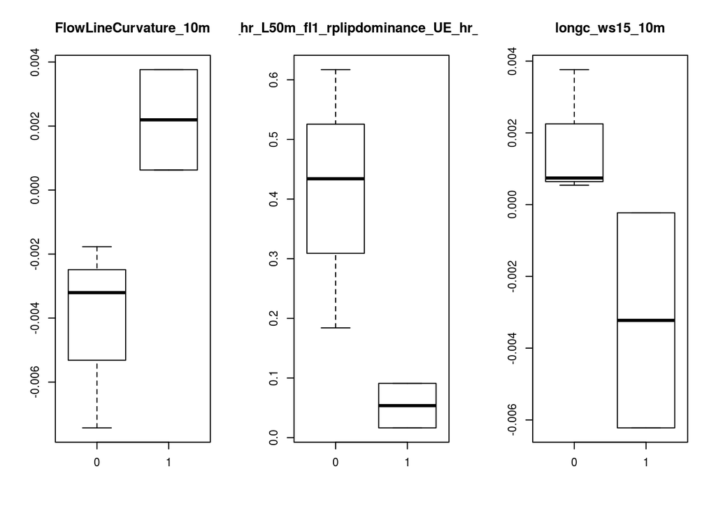

How about intermediate sedimentary rock

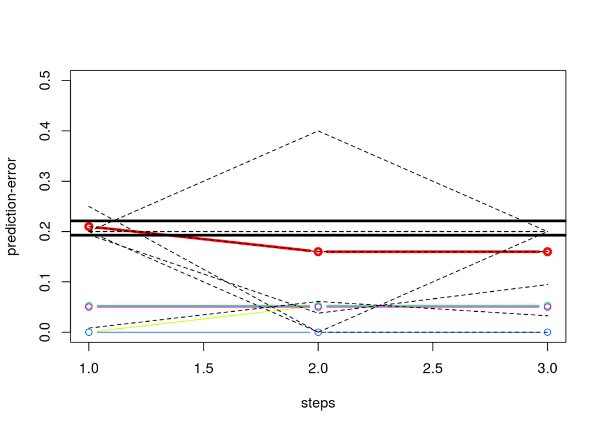

[1] “Prediction error at end is: 0.21” “Prediction error at end is: 0.16” [3] “Prediction error at end is: 0.16”

| k 1 | k 2 | k 3 | k 4 | k 5 |
| --- | --- | --- | --- | --- |
| profc_DTM_50m_avg_ws11_50m | geom_hr_L3_fl1_rplipsimpson_UE_hr_60cells_hr | slope_DTM_50m_avg_ws9_50m | SlopeHeight_10m | terraintexture_hr_ws41_tp5 |
| SlopeHeight_10m | SlopeHeight_10m | crosc_ws11_hr_hr | Slope_Height_50m | SlopeHeight_10m |
| terraintexture_hr_ws53_tp25 | Tangential_Curvature_50m | geom_hr_L3_fl1_rplipedgedensity_UE_hr_40cells_hr | slope_DTM_50m_avg_ws9_50m | Mid_Slope_Positon_50m |

[1] “OBB error with all predictors of allpreds is 0.208333333333333”

|  | CSR | ISR | MeanDecreaseAccuracy | MeanDecreaseGini |
| --- | --- | --- | --- | --- |
| SlopeHeight_10m | 0.0310000 | 0.0105968 | 0.0148760 | 0.3537216 |
| slope_DTM_50m_avg_ws11_50m | 0.0220000 | 0.0072103 | 0.0099722 | 0.2423200 |
| Slope_Height_50m | 0.0225000 | 0.0056041 | 0.0086532 | 0.3036432 |
| slope_DTM_50m_avg_ws7_50m | 0.0125000 | 0.0028405 | 0.0045755 | 0.1167677 |
| VerticalDistancetoChannelNetwork_10m | 0.0033333 | 0.0014484 | 0.0020333 | 0.1884405 |
| slope_DTM_50m_avg_ws9_50m | 0.0030000 | 0.0007857 | 0.0014889 | 0.1549528 |
| longc_ws7_10m | 0.0026667 | 0.0011548 | 0.0013944 | 0.0816487 |
| GeneralCurvature_10m | 0.0026667 | 0.0009476 | 0.0013859 | 0.0587851 |
| TRI_hr_ws49 | 0.0030000 | 0.0011389 | 0.0013500 | 0.0295599 |
| MidSlope_Positon_hr | 0.0023333 | 0.0008571 | 0.0012500 | 0.0814953 |

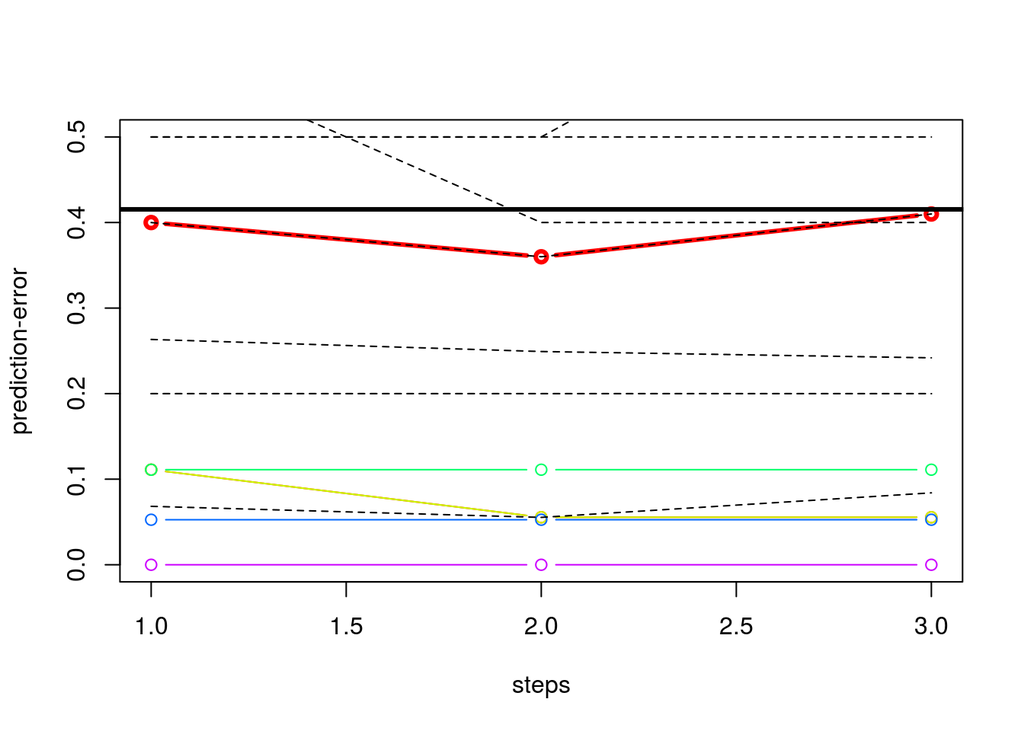

[1] “Prediction error at end is: 0.4” “Prediction error at end is: 0.36” [3] “Prediction error at end is: 0.41”

| k 1 | k 2 | k 3 | k 4 | k 5 |
| --- | --- | --- | --- | --- |
| geom_hr_L3_fl1_rplipdominance_UE_hr_10cells_hr | geom_hr_L50m_fl1_rplippatchdensity_UE_hr_10cells_hr | fischerk_ws27_hr | terraintexture_hr_ws53_tp25 | terraintexture_hr_ws41_tp5 |
| geom_hr_L50m_fl10_rplipshannon_UE_hr_60cells_hr | geom_hr_L50m_fl10_rplipmps_UE_hr_40cells_hr | vectorstrength_hr_ws27_hr | geom_hr_L50m_fl1_rplipsimpson_UE_hr_10cells_hr | geom_hr_L50m_fl10_rplippatchdensity_UE_hr_10cells_hr |
| geom_hr_L3_fl1_rplipmps_UE_hr_5cells_hr | geom_hr_L50m_fl1_rplipmps_UE_hr_10cells_hr | geom_hr_L3_fl10_rplipedgedensity_UE_hr_5cells_hr | terraintexture_hr_ws53_tp5 | geom_hr_L50m_fl10_rplippatchnum_UE_hr_10cells_hr |

[1] “OBB error with all predictors of roughness is 0.291666666666667”

|  | CSR | ISR | MeanDecreaseAccuracy | MeanDecreaseGini |
| --- | --- | --- | --- | --- |
| TRI_hr_ws46 | 0.0070000 | 0.0016579 | 0.0022714 | 0.0947232 |
| vectorruggedness_hr_ws5 | 0.0080000 | 0.0012571 | 0.0022690 | 0.1346314 |
| vectorruggedness_hr_ws7 | 0.0036667 | 0.0016817 | 0.0019579 | 0.1297445 |
| TRI_hr_ws50 | 0.0033333 | 0.0014667 | 0.0018810 | 0.0966136 |
| fischerk_ws5_hr | 0.0020000 | 0.0017738 | 0.0017066 | 0.0696358 |
| geom_hr_L50m_fl10_rplipshape_UE_hr_40cells_hr | 0.0010000 | 0.0019976 | 0.0016904 | 0.0555866 |
| geom_hr_L50m_fl10_rplipshannon_UE_hr_60cells_hr | 0.0020000 | 0.0013333 | 0.0015357 | 0.0644004 |
| geom_hr_L3_fl10_rplipdominance_UE_hr_40cells_hr | 0.0015000 | 0.0011548 | 0.0014802 | 0.0645633 |
| geom_hr_L50m_fl10_rplipsimpson_UE_hr_60cells_hr | 0.0046667 | 0.0007270 | 0.0013921 | 0.0481201 |
| terraintexture_hr_ws17_tp5 | 0.0020000 | 0.0009444 | 0.0012000 | 0.0084085 |

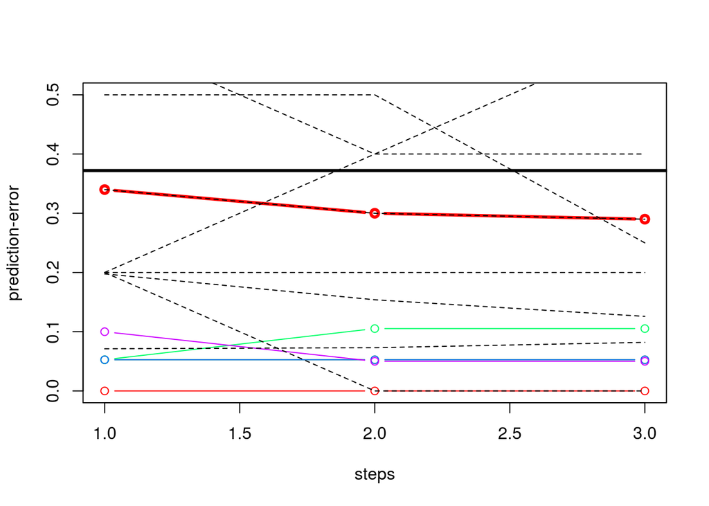

[1] “Prediction error at end is: 0.34” “Prediction error at end is: 0.3” [3] “Prediction error at end is: 0.29”

| k 1 | k 2 | k 3 | k 4 | k 5 |
| --- | --- | --- | --- | --- |
| longc_ws11_10m | maxic_DTM_50m_avg_ws7_50m | profc_DTM_50m_avg_ws11_50m | profc_DTM_50m_avg_ws11_50m | maxic_DTM_50m_avg_ws9_50m |
| profc_ws7_10m | maxic_DTM_50m_avg_ws9_50m | slope_DTM_50m_avg_ws5_50m | crosc_ws5_hr_hr | slope_DTM_50m_avg_ws7_50m |
| longc_ws15_hr_hr | Convergence_Index_hr | slope_DTM_50m_avg_ws7_50m | planc_ws5_hr_hr | planc_ws5_hr_hr |

[1] “OBB error with all predictors of localterrain is 0.208333333333333”

|  | CSR | ISR | MeanDecreaseAccuracy | MeanDecreaseGini |
| --- | --- | --- | --- | --- |
| slope_DTM_50m_avg_ws11_50m | 0.0350000 | 0.0097944 | 0.0143864 | 0.6154779 |
| slope_DTM_50m_avg_ws7_50m | 0.0208333 | 0.0052881 | 0.0087517 | 0.2932276 |
| slope_DTM_50m_avg_ws9_50m | 0.0158333 | 0.0029802 | 0.0048128 | 0.2535959 |
| MinimalCurvature_10m | 0.0040000 | 0.0038095 | 0.0036476 | 0.1467926 |
| maxic_DTM_50m_avg_ws5_50m | 0.0020000 | 0.0027738 | 0.0027198 | 0.0815979 |
| crosc_ws5_hr_hr | 0.0010000 | 0.0026444 | 0.0023722 | 0.0801994 |
| slope_DTM_50m_avg_ws5_50m | 0.0041667 | 0.0017857 | 0.0021273 | 0.1643573 |
| GeneralCurvature_10m | 0.0040000 | 0.0013992 | 0.0019348 | 0.1176222 |
| planc_DTM_50m_avg_ws5_50m | 0.0000000 | 0.0022056 | 0.0015294 | 0.0424514 |
| profc_DTM_50m_avg_ws3_50m | 0.0010000 | 0.0013611 | 0.0013867 | 0.0735622 |

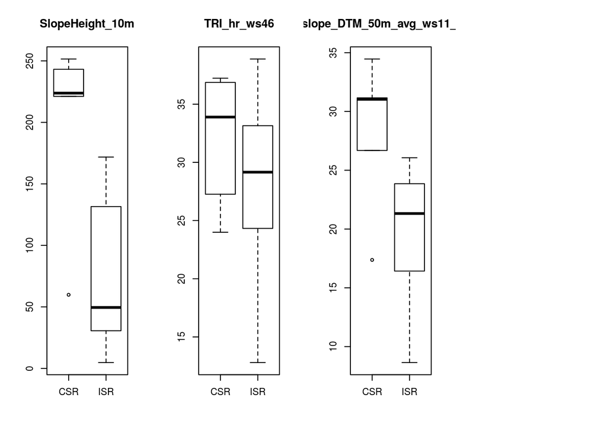

How does this compare to the differences between the units on the geological map?

[1] “OBB error with all predictors of allpreds is 0.0200210748155954”

|  | CSR | ISR | MeanDecreaseAccuracy | MeanDecreaseGini |
| --- | --- | --- | --- | --- |
| slope_DTM_50m_avg_ws9_50m | 0.0029550 | 0.0022246 | 0.0029454 | 0.3573058 |
| elev_ws5_10m | 0.0029362 | 0.0018627 | 0.0029312 | 0.1729140 |
| elev_ws3_10m | 0.0026352 | 0.0045883 | 0.0026895 | 0.1307364 |
| slope_DTM_50m_avg_ws11_50m | 0.0023990 | 0.0001857 | 0.0023625 | 0.2850595 |
| elev_ws11_10m | 0.0023514 | 0.0007652 | 0.0023477 | 0.2856243 |
| slope_ws7_10m | 0.0023676 | -0.0010127 | 0.0023069 | 0.0995540 |
| TRI_hr_ws31 | 0.0021090 | -0.0020000 | 0.0020487 | 0.0502890 |
| slope_ws15_10m | 0.0020518 | -0.0012968 | 0.0019937 | 0.1185254 |
| elev_ws15_10m | 0.0019379 | 0.0042302 | 0.0019738 | 0.2163426 |
| TRI_hr_ws27 | 0.0019359 | -0.0010825 | 0.0018792 | 0.0700136 |

[1] “OBB error with all predictors of roughness is 0.0200210748155954”

|  | CSR | ISR | MeanDecreaseAccuracy | MeanDecreaseGini |
| --- | --- | --- | --- | --- |
| TRI_hr_ws37 | 0.0058923 | -0.0018278 | 0.0057533 | 0.1553052 |
| TRI_hr_ws20 | 0.0054004 | -0.0051079 | 0.0052018 | 0.2012509 |
| TRI_hr_ws19 | 0.0051984 | -0.0016452 | 0.0050737 | 0.1898073 |
| TRI_hr_ws24 | 0.0052232 | -0.0035825 | 0.0050627 | 0.1372990 |
| TRI_hr_ws16 | 0.0051365 | -0.0074349 | 0.0049053 | 0.2073962 |
| TRI_hr_ws34 | 0.0044423 | 0.0003556 | 0.0043500 | 0.1055498 |
| TRI_hr_ws48 | 0.0045640 | -0.0070444 | 0.0043460 | 0.1974200 |
| TRI_hr_ws44 | 0.0044940 | -0.0065865 | 0.0043166 | 0.2183705 |
| TRI_hr_ws25 | 0.0043603 | -0.0045729 | 0.0041853 | 0.1633221 |
| TRI_hr_ws32 | 0.0041977 | 0.0011731 | 0.0041288 | 0.0962765 |

[1] “OBB error with all predictors of localterrain is 0.0200210748155954”

|  | CSR | ISR | MeanDecreaseAccuracy | MeanDecreaseGini |
| --- | --- | --- | --- | --- |
| longc_DTM_50m_avg_ws11_50m | 0.0028401 | 0.0065968 | 0.0028824 | 0.5538223 |
| longc_DTM_50m_avg_ws9_50m | 0.0025535 | 0.0044286 | 0.0025535 | 0.3956632 |
| profc_DTM_50m_avg_ws9_50m | 0.0024775 | 0.0015499 | 0.0024748 | 0.4565861 |
| profc_DTM_50m_avg_ws11_50m | 0.0019559 | 0.0119645 | 0.0021093 | 0.6605180 |
| slope_ws11_10m | 0.0019432 | 0.0018921 | 0.0019440 | 0.2200956 |
| slope_ws15_10m | 0.0019505 | 0.0024833 | 0.0019424 | 0.4096351 |
| Slope_10m | 0.0018190 | -0.0018881 | 0.0017603 | 0.2077280 |
| slope_ws29_hr_hr | 0.0017752 | -0.0025937 | 0.0017017 | 0.2306458 |
| slope_DTM_50m_avg_ws7_50m | 0.0017074 | 0.0012524 | 0.0016905 | 0.3627324 |
| slope_ws11_hr_hr | 0.0016304 | -0.0025190 | 0.0015637 | 0.1737306 |

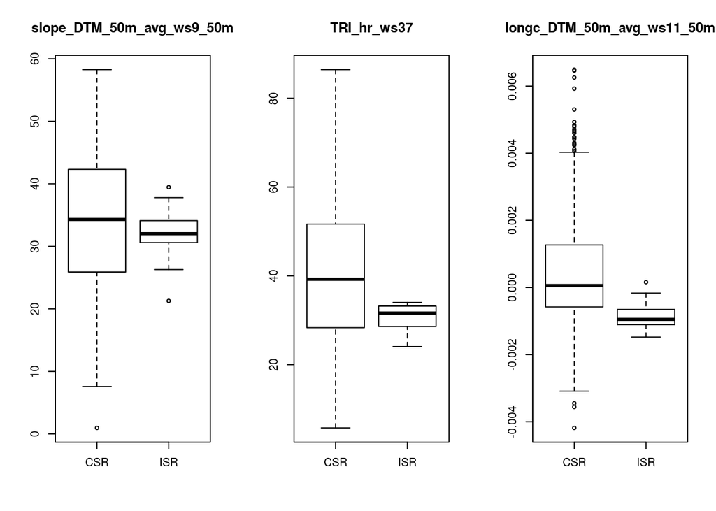